# SCA_SS24_Gruppe204_HA3

```r
## (b) Top 5 Faktoren mit der höchsten Korrelation auswählen und anzeigen
top5_correlations <- correlations_df %>%
  arrange(desc(abs(Correlation))) %>%
  head(5)
kable(top5_correlations, caption = "Die 5 am stärksten zur IFR korrelierenden externen Effekten")
```

Die 5 am stärksten zur IFR korrelierenden externen Effekten

| Factor | Correlation |
| --- | --- |
| UnskilledLaborAvailability | -0.8329434 |
| Inflation | 0.8213916 |
| PoliticalStability | 0.8105602 |
| AvgHealth | -0.7821141 |
| Criminality | 0.7139624 |

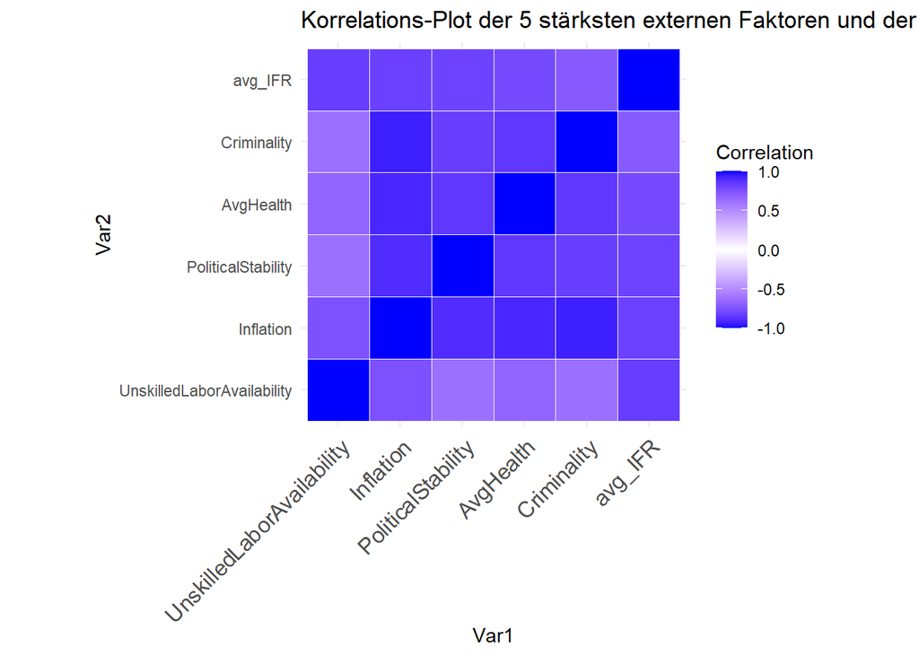

```r
## (c) Korrelationen für die Top 5 Faktoren visualisieren
# Baseline hesaplama (ort. IFR)
# Extraktion der 5 Faktoren
correlation_data <- gifter_externals %>%
  select(all_of(top5_correlations$Factor), avg_IFR)
# Berechnung der Korrelationen zwischen den Faktoren und der IFR
correlation_matrix <- cor(correlation_data, use = "complete.obs")
correlation_melt <- melt(correlation_matrix)
# Visualisierung der Korrelationen
ggplot(data = correlation_melt, aes(Var1, Var2, fill = value)) +
  geom_tile(color = "white") +
  scale_fill_gradient2(low = "blue", high = "blue", mid = "white",
                       midpoint = 0, limit = c(-1,1), space = "Lab",
                       name = "Correlation") +
  theme_minimal() +
  theme(axis.text.x = element_text(angle = 45, vjust = 1,
                                   size = 12, hjust = 1)) +
  coord_fixed() +
  labs(title = "Korrelations-Plot der 5 stärksten externen Faktoren und der IFR")
```

6. Sie möchten nun eine Lineare Regression durchführen, um die IFR mit Hilfe der externen Effekte vorherzusagen. Um die Güte Ihrer Modelle vergleichen zu können, benötigen Sie eine geeignete Baseline. Erzeugen Sie eine sin‐ nvolle Baseline in dem Dataframe zu Ihrem gewählten Warehousing‐DL in einer Variable Baseline. Begründen Sie Ihre Wahl. Geben Sie von dem DataFrame den Tabellenkopf aus. Geben Sie Sie nur die Spalten ‘Periode’, ‘Region’, ‘IFR’ und ‘Baseline’ aus. Bewertungsrelevant: Output, Begründung.

```r
## Durchschnittliche IFR als Baseline ausgewählt, da sie den zentralen Tendenz der vorhandenen Daten repräsentiert und einen einfachen Referenzpunkt vor der Erstellung eines komplexen Modells bietet. So kann die durchschnittliche Leistung des erstellten Modells im Vergleich zu dieser zentralen Tendenz bewertet werden. Der Durchschnittswert ist oft eine der einfachsten und effektivsten Metriken, um das allgemeine Verhalten der Daten zusammenzufassen.
# Berechnung des historischen Durchschnitts-IFR als Baseline
historical_avg_IFR <- mean(gifter_externals$avg_IFR, na.rm = TRUE)
# Hinzufügen der Baseline-Spalte zum DataFrame
gifter_externals <- gifter_externals %>%
  mutate(Baseline = historical_avg_IFR)
# Ausgabe der relevanten Spalten
gifter_baseline_output <- gifter_externals %>%
  select(Periode, region, avg_IFR, Baseline)
# Ausgabe des Tabellenkopfs
head(gifter_baseline_output)
```

```
##   Periode region   avg_IFR  Baseline
## 1  201901  Japan 0.8215646 0.8250903
## 2  201902  Japan 0.8202110 0.8250903
## 3  201903  Japan 0.8043408 0.8250903
## 4  201904  Japan 0.8221602 0.8250903
## 5  201905  Japan 0.8209567 0.8250903
## 6  201906  Japan 0.8230232 0.8250903
```

7. Visualisieren Sie die Baseline Ihres gewählten LDL für den Zeitraum von 2019 bis 2023 sowie die IFR in der Region Shanghai und die IFR in der Region Peking Bewertungsrelevant: Output.

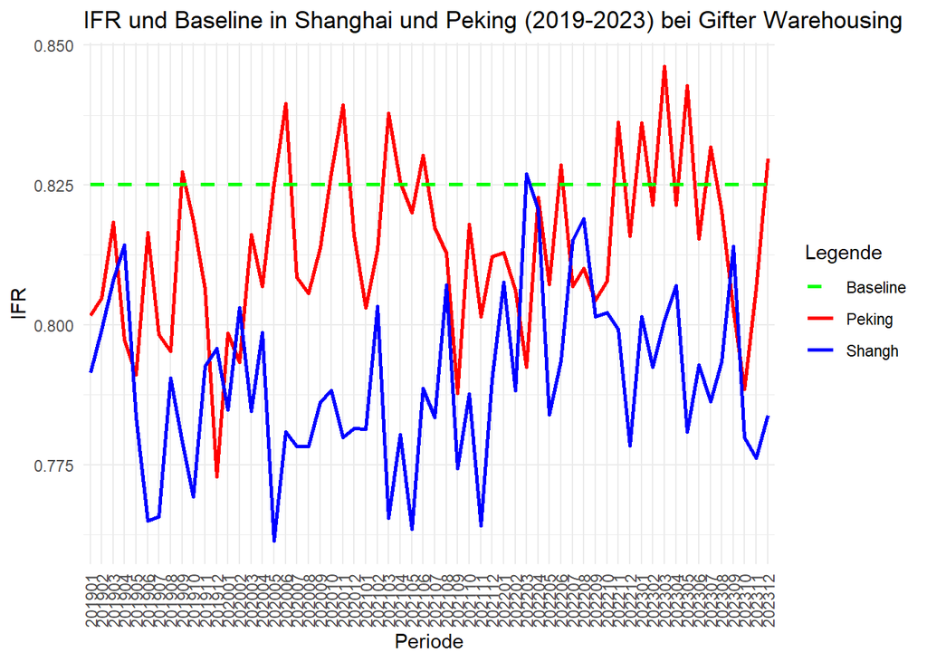

```r
# Filtern der Daten für die Regionen Shanghai und Peking
gifter_shanghai_peking <- gifter_externals %>%
  filter(region %in% c("Shangh", "Peking") & Periode >= 201901 & Periode <= 202312)

# Visualisierung der Baseline und IFR-Werte für Shanghai und Peking
ggplot(gifter_shanghai_peking, aes(x = Periode, group = region)) +
  geom_line(aes(y = avg_IFR, color = region), size = 1) +
  geom_line(aes(y = Baseline, color = "Baseline"), linetype = "dashed", size = 1) +
  labs(title = "IFR und Baseline in Shanghai und Peking (2019-2023) bei Gifter Warehousing",
       x = "Periode",
       y = "IFR",
       color = "Legende") +
  scale_color_manual(values = c("Shangh" = "blue", "Peking" = "red", "Baseline" = "green")) +
  theme_minimal() +
  theme(axis.text.x = element_text(angle = 90, vjust = 0.5, hjust = 1))
```

8. Bewerten Sie die Baseline für Ihren gewählten Warehousing‐Logistikdienstleister nach MAE und MAPE und spe‐ ichern Sie diese in einem Dataframe (z.B. “evaluation”) ab. Dieses Dataframe soll später auch für die Bewertung der Regressionsmodelle genutzt werden. Fügen Sie zudem auch eine Spalte für das Bestimmtheitsmass (R²) sowie das adjustierte Bestimmtheitsmass (adj. R²) hinzu, welche im Falle der Baseline 0 sein können. Bewer‐ tungsrelevant: Output.

```r
# Berechnung von MAE und MAPE
baseline_mae = mean(abs(gifter_externals$avg_IFR - gifter_externals$Baseline), na.rm = TRUE)
baseline_mape = mean(abs((gifter_externals$avg_IFR - gifter_externals$Baseline)/gifter_externals$avg_IFR)*100, na.rm = TRUE)

# Erstellung des neuen Dataframes zur Speicherung von MAE und MAPE
evaluation = data.frame(
  Model = "Baseline",
  MAE = baseline_mae,
  MAPE = baseline_mape,
  R2 = 0,
  adj_R2 = 0
)
evaluation
```

```
##      Model        MAE     MAPE R2 adj_R2
## 1 Baseline 0.02812247 3.372565  0      0
```

9. Teilen Sie das Dataframe Ihres gewählten Warehousing‐Logistikdienstleisters in ein Trainings‐ (80%) und ein Test‐ Set (20%) auf. Geben Sie von beiden den Tabellenkopf aus. Setzen Sie vorher den Seed 4141. Bewertungsrele‐ vant: Code, Output.

```r
# Seed 4141 für Reproduzierbarkeit
set.seed(4141)

# Aufteilung der Daten in Trainings- (80%) und Test-Set (20%)
sample_size <- floor(0.8 * nrow(gifter_externals))
train_indices <- sample(seq_len(nrow(gifter_externals)), size = sample_size)
train_set <- gifter_externals[train_indices, ]
test_set <- gifter_externals[-train_indices, ]

# Ausgabe der Tabellenköpfe
head(train_set)
```

```
##     region Periode             vendor   avg_IFR   X Year Month Period
## 52   Japan  202304 Gifter Warehousing 0.8370769 258 2023     4 2023/4
## 295 Skorea  201907 Gifter Warehousing 0.8917266  34 2019     7 2019/7
## 281 Shangh  202405               <NA>        NA 321 2024     5 2024/5
## 333 Skorea  202209 Gifter Warehousing 0.8810750 224 2022     9 2022/9
## 39   Japan  202203 Gifter Warehousing 0.8371107 193 2022     3 2022/3
## 327 Skorea  202203 Gifter Warehousing 0.8895385 194 2022     3 2022/3
##     Temperature_C Rain_mm Sunshine_h Humidity Congestion InternetStability
## 52         10.215  41.735    168.005   61.424      47.87              1758
## 295        19.573  63.539    283.932   66.910      64.47                64
## 281        10.818  49.595    290.481   62.022      65.73               347
## 333        17.687  52.035    179.996   70.788      51.79                70
## 39          7.520  36.679    124.040   65.490      42.47              1944
## 327        -2.203  40.916    113.034   82.205      45.38                67
##     PowerGridStability ParkingSpaceAvailability RoadCondition
```

[output cut: 34 more lines]